# Take-home Exercise 1

In this Take-home Exercise, I will explore using appropriate static statistical graphic methods to understand the demographic of the city of Engagement, Ohio USA.

Jeremiah Lam https://sg.linkedin.com/in/jeremiah-lam-6156238a (School of Computing and Information Systems)https://scis.smu.edu.sg/  
2022-04-24

# Overview

In this take-home exercise, appropriate static statistical graphic methods are used to reveal the demographic of the city of Engagement, Ohio USA.

The data is processed by using appropriate tidyverse family of packages and the statistical graphics are prepared using ggplot2 and its extensions.

# Getting Started

Before getting started, it is important to ensure that the required R packages have been installed. If yes, we will load the R packages. If they have yet to be installed, we will install the R packages and load them onto R environment.

The chunk code below will do the trick.

```r
packages = c('tidyverse')

for(p in packages){
  if(!require(p, character.only = T)){
    install.packages(p)
  }
  library(p, character.only = T)
}
```

# Importing Data

The code chunk below imports *Participants.csv* from the data folder into R by using [`read_csv()`](https://readr.tidyverse.org/reference/read_delim.html) of [**readr**](https://readr.tidyverse.org/reference/index.html) package and saves it as a tibble data frame called *Participants*.

```r
Participants <- read_csv("data/Participants.csv")
```

# A Simple Bar Chart

The code chunk below segments the data imported from *Participants.csv* by using [`ggplot()`](https://ggplot2.tidyverse.org/reference/ggplot.html) of [**ggplot2**](https://ggplot2.tidyverse.org/) package as well as `geom_bar()` to create the stacked bar graph and `geom_text()` to label the created graph with the appropriate values.

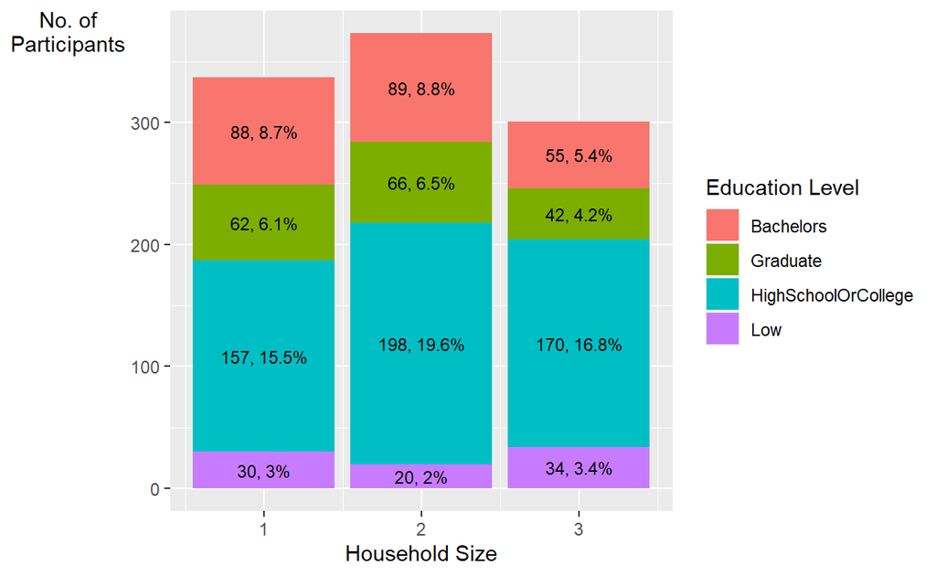

```r
ggplot(Participants, aes(x=householdSize, fill = educationLevel)) +
  geom_bar() +
  geom_text(stat="count",
            aes(label=paste0(..count..,", ",
                             round(..count../sum(..count..)*100,
                                   1),"%")),
            position = position_stack(vjust = 0.5), size = 3) +
  xlab("Household Size") +
  ylab("No. of\nParticipants") +
  labs(fill = "Education Level") +
  theme(axis.title.y=element_text(angle=0))
```

From this graph, we can observe that Participants who have a High school education or lower tend to come from household sizes of 2 or 3, which may be be due to other commitments and pursuits they might have currently (e.g. taking care of their kids or getting a job early to support their family).

# A Simple Boxplot

The code chunk below dissects the data imported from *Participants.csv* by using [`ggplot()`](https://ggplot2.tidyverse.org/reference/ggplot.html) of [**ggplot2**](https://ggplot2.tidyverse.org/) package as well as `geom_boxplot()` to create the box plot graph, `facet_grid()` and `labeller()` to help visualize the joviality levels across different household sizes and whether there are children living in the household.

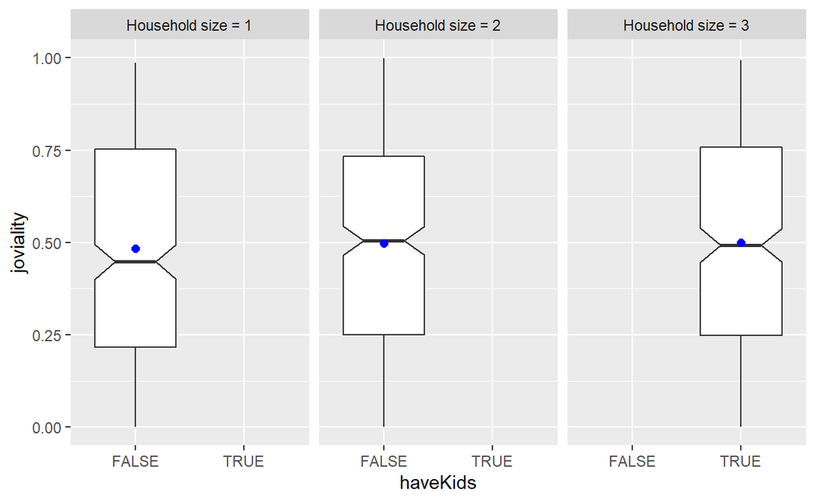

```r
new <- c("Household size = 1", "Household size = 2", "Household size = 3")
names(new) <- c("1", "2", "3")
ggplot(data = Participants,
       aes(y = joviality, x = haveKids)) +
  geom_boxplot(notch = TRUE) +
  facet_grid(~ householdSize, labeller = labeller(householdSize = new)) +
  stat_summary(geom ="point",
              fun.y = "mean",
              colour = "blue",
              size = 2)
```

The code chunk below dissects the data in a slightly different manner, albeit still using the box plot graph, it helps to visualize the joviality levels across different education levels.

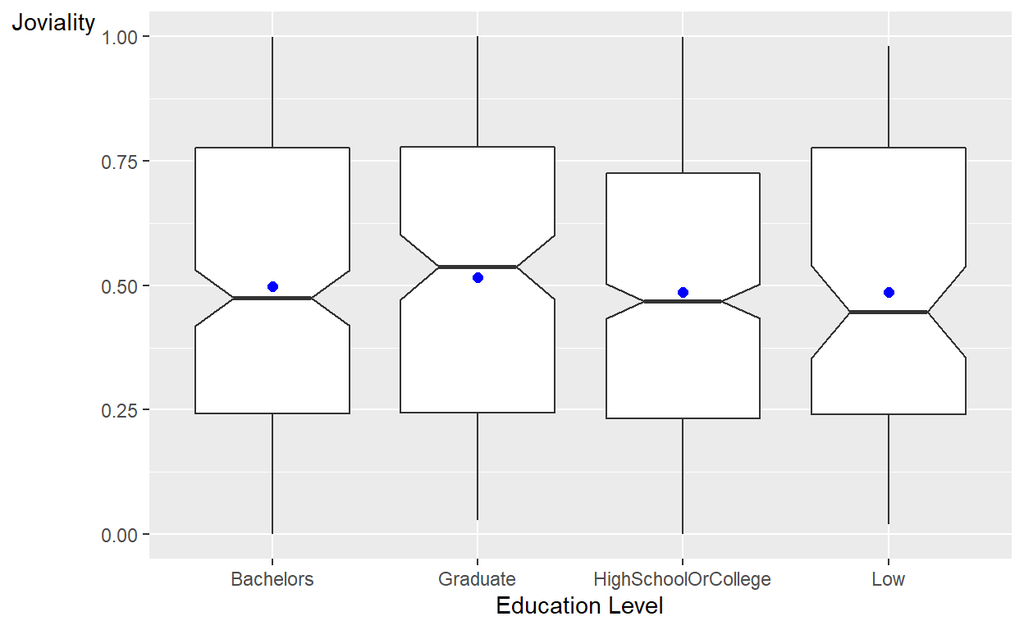

```r
ggplot(data = Participants,
       aes(y = joviality, x = educationLevel)) +
  geom_boxplot(notch = TRUE) +
  stat_summary(geom ="point",
              fun.y = "mean",
              colour = "blue",
              size = 2) +
  ylab("Joviality") +
  xlab("Education Level") +
  theme(axis.title.y=element_text(angle=0))
```

Based on the graph above, it is interesting to observe that the median and mean joviality levels (annotated by the notched line and blue dot respectively) of those with a higher education level are higher as well.

# A Simple Histogram

Lastly, the code chunk below dissects the data imported from *Participants.csv* by using [`ggplot()`](https://ggplot2.tidyverse.org/reference/ggplot.html) of [**ggplot2**](https://ggplot2.tidyverse.org/) package as well as `geom_histogram()` to create a histogram to help visualize the age range across participants and `geom_vline` to observe the mean and median age.

Based on the graph further below, it is interesting to note that the largest amount of participants come from those in their early 30s, whilst the median and mean age of participants is close to 40, which may be indicative of an aging population.

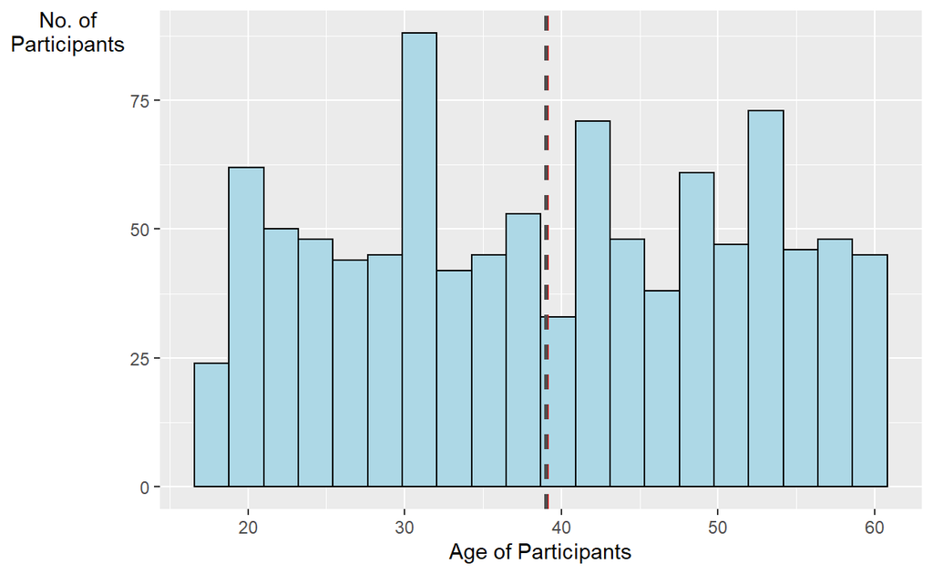

```r
ggplot(data=Participants,
       aes(x= age)) +
  geom_histogram(bins=20,
                 color = 'black',
                 fill='light blue') +
  geom_vline(aes(xintercept=mean(age,
                                 na.rm=T)),
             color="red",
             linetype='dashed',
             size=1) +
  geom_vline(aes(xintercept=median(age,
                                 na.rm=T)),
             color="grey30",
             linetype='dashed',
             size=1) +
  ylab("No. of\nParticipants") +
  xlab("Age of Participants") +
  theme(axis.title.y=element_text(angle=0))
```